# Preparation

## 1.2. Latent factors without domain specification

**Kaiser-Meyer-Olkin test**:

```
## ℹ 'x' was not a correlation matrix. Correlations are found from entered raw data.
```

```
##
## ── Kaiser-Meyer-Olkin criterion (KMO) ──────────────────────────────────────────
##
## ! The overall KMO value for your data is mediocre.
##   These data are probably suitable for factor analysis.
##
##   Overall: 0.661
##
##   For each variable:
##                      SEGM_RT_training                     SEGM_RT_TRN3_RND4
##                                 0.579                                 0.515
##                     SEGM_RT_RND4_REC5                     SEGM_ACC_training
##                                 0.554                                 0.348
##                    SEGM_ACC_TRN3_RND4                    SEGM_ACC_RND4_REC5
##                                 0.418                                 0.351
##                      SEGM_2AFC_bigram                     SEGM_2AFC_trigram
##                                 0.577                                 0.692
##                       SEGM_production                      AGL_ACC_training
##                                 0.739                                 0.423
##                       AGL_2AFC_phrase                     AGL_2AFC_sentence
##                                 0.649                                 0.853
##                        AGL_production            perceptual_speed_visual_RT
##                                 0.703                                 0.750
##          perceptual_speed_auditory_RT      perceptual_speed_visual_decision
##                                 0.676                                 0.871
##                    digit_span_forward                   digit_span_backward
##                                 0.752                                 0.655
##                   nback_1_back_dprime                   nback_2_back_dprime
##                                 0.714                                 0.681
##                   nback_3_back_dprime                             stroop_RT
##                                 0.726                                 0.770
##                       stroop_accuracy                              simon_RT
##                                 0.657                                 0.761
##                        simon_accuracy               grammatical_sensitivity
##                                 0.436                                 0.713
##                    one_minute_reading               predictive_sent_proc_RT
##                                 0.705                                 0.751
##         predictive_sent_proc_accuracy           selfpaced_gardenpath_target
##                                 0.487                                 0.622
## selfpaced_violation_processing_target               pragmatic_comprehension
##                                 0.681                                 0.820
```

The previously identified indices with unsatisfactory fit for EFA (MSA < 0.5) show similarly worse fit in this model resulting in their exclusion: - SEGM_ACC_training [speech segmentation - SEGM ACC training] - SEGM_ACC_TRN3_RND4 [speech segmentation - SEGM ACC TRN3-RND4] - SEGM_ACC_RND4_REC5 [speech segmentation - SEGM ACC RND4-REC5] - AGL_ACC_training [artificial grammar learning - AGL ACC training]

After their exclusion, KMO test was repeated.

```
## ℹ 'x' was not a correlation matrix. Correlations are found from entered raw data.
```

```
##
## ── Kaiser-Meyer-Olkin criterion (KMO) ──────────────────────────────────────────
##
## ✔ The overall KMO value for your data is middling.
##   These data are probably suitable for factor analysis.
##
##   Overall: 0.707
##
##   For each variable:
##                      SEGM_RT_training                     SEGM_RT_TRN3_RND4
##                                 0.608                                 0.526
##                     SEGM_RT_RND4_REC5                      SEGM_2AFC_bigram
##                                 0.570                                 0.595
##                     SEGM_2AFC_trigram                       SEGM_production
##                                 0.695                                 0.799
##                       AGL_2AFC_phrase                     AGL_2AFC_sentence
##                                 0.650                                 0.869
##                        AGL_production            perceptual_speed_visual_RT
##                                 0.708                                 0.753
##          perceptual_speed_auditory_RT      perceptual_speed_visual_decision
##                                 0.686                                 0.888
##                    digit_span_forward                   digit_span_backward
##                                 0.758                                 0.652
##                   nback_1_back_dprime                   nback_2_back_dprime
##                                 0.766                                 0.682
##                   nback_3_back_dprime                             stroop_RT
##                                 0.742                                 0.770
##                       stroop_accuracy                              simon_RT
##                                 0.653                                 0.807
##                        simon_accuracy               grammatical_sensitivity
##                                 0.469                                 0.733
##                    one_minute_reading               predictive_sent_proc_RT
##                                 0.726                                 0.767
##         predictive_sent_proc_accuracy           selfpaced_gardenpath_target
##                                 0.479                                 0.640
## selfpaced_violation_processing_target               pragmatic_comprehension
##                                 0.672                                 0.821
```

**Bartlett’s test**:

```
## ℹ 'x' was not a correlation matrix. Correlations are found from entered raw data.
```

```
##
## ✔ The Bartlett's test of sphericity was significant at an alpha level of .05.
##   These data are probably suitable for factor analysis.
##
##   𝜒²(378) = 4363.58, p < .001
```

**Parallel analysis**:

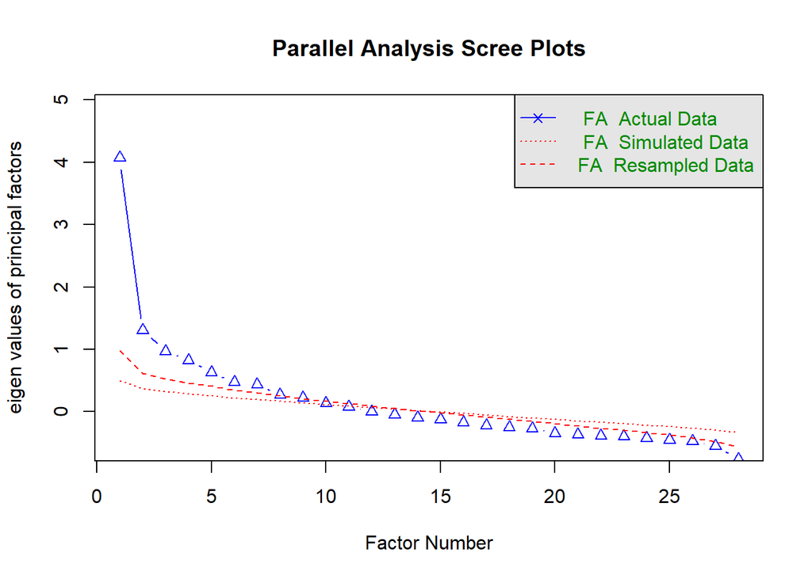

```
## Parallel analysis suggests that the number of factors =  10  and the number of components =  NA
```

Parallel analysis suggests that the number of factors formed should be 10. Notice that based on the scree plot, one factor emerges as a crucial latent variable. This could be due to the well-described phenomenon of the positive manifold in cognitive abilities in which the solitary factor would be the g factor (independent of whether we see it as a formative or reflective variable, for further details see Process Overlap Theory (Kovacs & Conway, 2016))